# Week 2 Data Preparation, Exploratory Data Analysis and Visualization

## Theory and Practice

### Ying Lin, Ph.D

## Outline of the Topics

- A standard machine learning pipeline
- Dataset types, attribute types and conversion
- Data quality issues and cleaning/transformation/preprocessing
- Exploratory data analysis and visualization
- Python demo

## A Standard Machine Learning Pipeline

[figure not shown]

## Dataset Types

- Structured data: Record dataset
  - Row: object, record, example
  - Column: feature, attribute, variable
- Unstructured data
  - Market basket data
  - Text data
  - Image data
  - Sequence data

## Attribute Types

- Categorical (Qualitative)
  - Nominal: e.g. name, zip code
  - Ordinal: e.g. rating, rank
- Numerical (Quantitative)
  - Interval: e.g. IQ, temperature in fahrenheit, date
  - Ratio: e.g. height, weight
- Properties of Attributes
  - Distinctness
  - Order
  - Substraction
  - Division

```python
import pandas as pd

mpg = pd.read_csv("https://raw.githubusercontent.com/tidyverse/ggplot2/master/data-raw/mpg.csv")
# mpg.dtypes
mpg.info()
```

```
<class 'pandas.core.frame.DataFrame'>
RangeIndex: 234 entries, 0 to 233
Data columns (total 11 columns):
 #   Column        Non-Null Count  Dtype
---  ------        --------------  -----
 0   manufacturer  234 non-null    object
 1   model         234 non-null    object
 2   displ         234 non-null    float64
 3   year          234 non-null    int64
 4   cyl           234 non-null    int64
 5   trans         234 non-null    object
 6   drv           234 non-null    object
 7   cty           234 non-null    int64
 8   hwy           234 non-null    int64
 9   fl            234 non-null    object
 10  class         234 non-null    object
dtypes: float64(1), int64(4), object(6)
memory usage: 20.2+ KB
```

## Meta Data of "mpg" Data frame

| Variable | Description |
| --- | --- |
| manufacturer | carmarker |
| model | model name |
| displ | engine displacement (in litres) |
| year | year of manufacture |
| cyl | number of cylinders |
| trans | type of transmission |
| drv | f = front-wheel drive, r = rear wheel drive, 4 = 4wd |
| cty | city miles per gallon |
| hwy | highway miles per gallon |
| fl | fuel type |
| class | "type" of car |

## Discretization

- Discrete vs. continuous
- Discretization: one type of data transformation from a continuous attribute to a discrete one
  - Equal interval
  - Equal frequency
  - K-means
  - Equal entropy
- Some data mining and machine learning algorithms don't work with continuous attributes: decision tree induction, association rule mining, naive Bayes classifier

```python
mpg.select_dtypes('number').columns
mpg['cty2interval'] = pd.cut(mpg['cty'], bins=2) # equal interval discretization
mpg['cty2interval'].value_counts()
mpg['cty2freq'] = pd.qcut(mpg['cty'], q=2, labels=['low', 'high']) # equal frequency discretization
mpg['cty2freq'].value_counts()
```

```
Index(['displ', 'year', 'cyl', 'cty', 'hwy'], dtype='object')
```

```
(8.974, 22.0]    216
(22.0, 35.0]      18
Name: cty2interval, dtype: int64
```

```
low     132
high    102
Name: cty2freq, dtype: int64
```

## [Convert Categorical Attributes to Numerical Attributes](https://towardsdatascience.com/an-overview-of-categorical-input-handling-for-neural-networks-c172ba552dee)

- Label/integer encoding
  - Assume ordinal property of the categorical attributes
- One-hot encoding
  - Create the same number of dummy variables/binary attributes for the categorical attributes with the same number of possible values (minus one), i.e. dummify
- Target encoding
  - use the target attribute (categorical and numerical) to encode. Careful with overfitting.
- Frequency encoding
- [Embedding](https://towardsdatascience.com/neural-network-embeddings-explained-4d028e6f0526)
- When needed: regression, PCA, distance-based methods (KNN, clustering analysis), nueral network, SVM

```python
obj_col = mpg.select_dtypes('object').columns
for col in obj_col:
    print(f"{col} has {mpg[col].nunique()} unique values")

pd.concat([pd.get_dummies(mpg['drv']), mpg['drv']], axis=1)
```

```
manufacturer has 15 unique values
model has 38 unique values
trans has 10 unique values
drv has 3 unique values
fl has 5 unique values
class has 7 unique values
```

|  | 4 | f | r | drv |
| --- | --- | --- | --- | --- |
| 0 | 0 | 1 | 0 | f |
| 1 | 0 | 1 | 0 | f |
| 2 | 0 | 1 | 0 | f |
| 3 | 0 | 1 | 0 | f |
| 4 | 0 | 1 | 0 | f |
| ... | ... | ... | ... | ... |
| 229 | 0 | 1 | 0 | f |
| 230 | 0 | 1 | 0 | f |
| 231 | 0 | 1 | 0 | f |
| 232 | 0 | 1 | 0 | f |
| 233 | 0 | 1 | 0 | f |

234 rows × 4 columns

## Data Quality Issues

- Data noise vs. outliers
  - Risk of overfitting
- Missing values
  - Can't be tolerated by neural network, linear/logistic regression, etc.
- Duplicate data
- Multicollinearity
- Attributes with low to no variance
- Imbalanced dataset

```python
from scipy.stats.mstats import winsorize
np.min(mpg['cty'])
np.min(winsorize(mpg['cty'], limits=[0.1, 0.1]))
np.max(mpg['cty'])
np.max(winsorize(mpg['cty'], limits=[0.1, 0.1]))
print(f"There are {mpg.isna().sum().sum()} missing values.")
print(f"There are {mpg.duplicated().sum()} duplicated records.")
```

```
9
```

```
11
```

```
35
```

```
21
```

```
There are 0 missing values.
There are 9 duplicated records.
```

## Data Transformation

- Transformation based on rows (records, objects)
- Transformation based on columns (attributes, features)
- Aggregation and data roll-up
- Attribute transformation/feature engineering
- Sampling: e.g. bootstrap resampling
- Dimension reduction:
  - Principal Component Analysis (PCA): represent data in lower dimension and address multicollinearity
  - Remove attributes with low to no variance

## Aggregation

- Combine multiple attributes (or objects) into a single attribute (or object)
- Benefits
  - Data reduction
  - Reduce data variability
  - Change of analysis scale
  - Generate summary/descriptive analysis

```python
mpg.groupby('drv')['cty'].mean()
mpg.groupby('drv')['cty'].agg(['count', 'mean', 'std']).reset_index()
```

```
drv
4    14.330097
f    19.971698
r    14.080000
Name: cty, dtype: float64
```

|  | drv | count | mean | std |
| --- | --- | --- | --- | --- |
| 0 | 4 | 103 | 14.330097 | 2.874459 |
| 1 | f | 106 | 19.971698 | 3.626510 |
| 2 | r | 25 | 14.080000 | 2.215852 |

## Feature Engineering and Attribute Transformation

- Discretization and numerization
  - Many ML algorithms can only work with categorical or numerical attributes
- Apply transformation function, such as $\log(x)$, $e^x$, $x^k$, $\frac{1}{x}$
  - Reduce effects of outliers
- [Normalization and standardization (scale and center)](https://sebastianraschka.com/Articles/2014_about_feature_scaling.html)
- Algorithms that require both numerization and normalization
  - Distance-based algorithms: KNN, Cluster Analysis, kernel based methods such as SVM
  - Neural network and deep learning
  - PCA

```python
import scipy
mpg['cty_zscore'] = (mpg['cty'] - mpg['cty'].mean())/mpg['cty'].std()
mpg['cty_zscore'].describe()
```

```
count    2.340000e+02
mean     3.564041e-16
std      1.000000e+00
min     -1.846587e+00
25%     -6.717601e-01
50%      3.313615e-02
75%      5.030670e-01
max      4.262513e+00
Name: cty_zscore, dtype: float64
```

## Normalization and Standardization

- Z-score transformation: convert numerical values into the distance in standard deviation units form the mean.
  - $z_i = \frac{x_i - \overline{x}}{\sigma}$
- Min-Max standardization: Standardize the range of all the numerical attributes to [0, 1]
  - $f(x) = \frac{x - min}{max - min}$

## Sampling

- Create *representative* data samples with the similar properties as the original distribution
  - Sampling with vs. without replacement
  - Sample size
- Sampling Methods
  - Convenience sampling
  - Random sampling
  - Stratified sampling
  - Systematic sampling

```python
# permutation of the data frame
mpg.sample(frac=1).head(5)
mpg.shape
mpg.sample(frac=0.6).shape
```

|  | manufacturer | model | displ | year | cyl | trans | drv | cty | hwy | fl | class | cty2interval | cty2freq | cty_zscore |
| --- | --- | --- | --- | --- | --- | --- | --- | --- | --- | --- | --- | --- | --- | --- |
| 213 | volkswagen | jetta | 2.0 | 1999 | 4 | manual(m5) | f | 21 | 29 | r | compact | (8.974, 22.0] | high | 0.972998 |
| 217 | volkswagen | jetta | 2.5 | 2008 | 5 | auto(s6) | f | 21 | 29 | r | compact | (8.974, 22.0] | high | 0.972998 |
| 109 | hyundai | sonata | 2.4 | 1999 | 4 | manual(m5) | f | 18 | 27 | r | midsize | (8.974, 22.0] | high | 0.268102 |
| 214 | volkswagen | jetta | 2.0 | 1999 | 4 | auto(l4) | f | 19 | 26 | r | compact | (8.974, 22.0] | high | 0.503067 |
| 168 | subaru | impreza awd | 2.5 | 1999 | 4 | auto(l4) | 4 | 19 | 26 | r | subcompact | (8.974, 22.0] | high | 0.503067 |

```
(234, 14)
```

```
(140, 14)
```

## Exploratory Data Analysis (EDA)

- EDA is an iterative cycle
  - Generate questions/hypotheses about your data
  - Search for answers by cleaning, visualising, transforming and modeling your data
  - Use what you learn to refine your questions and generate new questions
- EDA is a state of minds: curiosity and inquisitiveness
  - EDA is fundamentally a creative process that is shaped by a series of Q & A
  - Key to asking *quality* questions is to generate a large *quantity* of questions followed up with data checking and exploration

## Visualization

- Multivariate analysis to intuitively recognize higher-dimensional data patterns and derive insights to guide data modeling
- Increase expressiveness through integrating more and various type of attributes
- Common visualization techniques and their variants
  - Basic types: histogram, box plot, bar chart, scatter plot, bubble chart, pie/donut pie chart, area graph, density plot, heatmap, etc.
  - Special types: word cloud, tree diagram, network diagram, radar chart, sankey diagram, etc.
  - Combination: faceted plot, dashboarding

```python
# Load in python visualization libraries

import matplotlib.pyplot as plt
import seaborn as sns
import plotly.express as px
%matplotlib inline
```

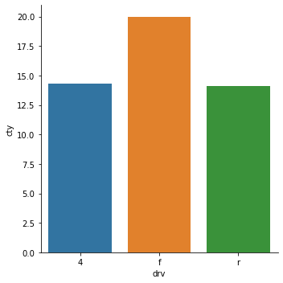

```python
cty_by_drv = mpg.groupby('drv')['cty'].mean().reset_index()
sns.catplot(x='drv', y='cty', data=cty_by_drv, kind='bar')
```

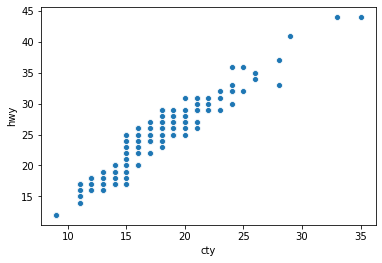

```python
# Scatter Plot
sns.scatterplot(x="cty", y="hwy", data=mpg)
```

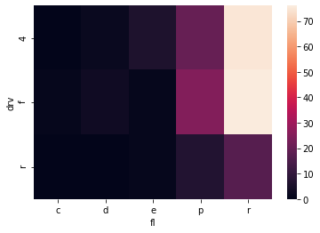

```python
# heatmap
cty_by_drv_fl = mpg.pivot_table(values='cty', index="drv", columns="fl", aggfunc='count', fill_value=0)
sns.heatmap(data=cty_by_drv_fl)
```